# Indel Signature InsDel2c

# InsDel2c

(corresponds to 83-type signature C_ID2)

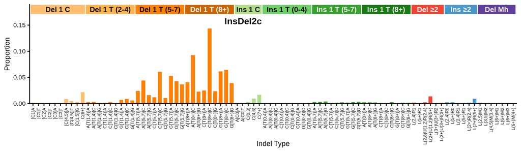

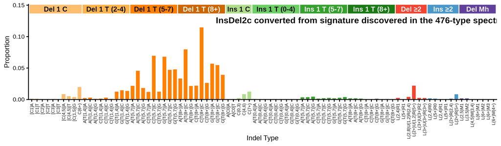

89-type spectrum of the linking tumor DRUP01330020T | cosine similarity to InsDel2c: 0.9744

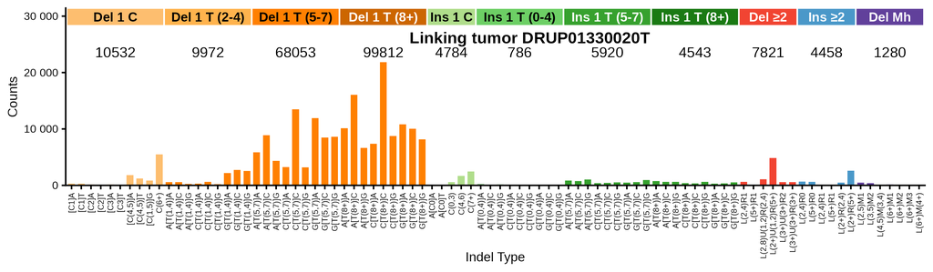

**Click to view decomposition of the linking tumor spectrum**

Partial mutation signature of DRUP01330020T due to InsDel2c

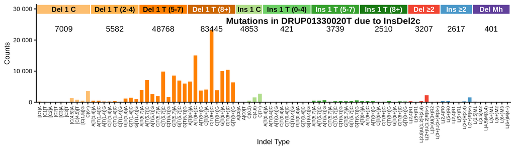

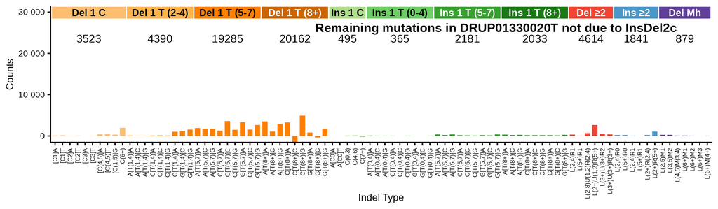

Max neg fraction (maximum allowed negative residual count as fraction of total): 0.01  
N subtract (mutation count assigned to signature): 162553.2  
N residual (mutation count in residual “partial spectrum”): 55407.8  
Total negative (sum of negative residual mutation counts): 2179.5  
N negative channels (number of channels with negative residual): 4  
P(≥ total negative) (Monte Carlo estimated probability that negative-binomial-sampled spectra from the signature contributing N subtract mutations would produce a total negative count >= the observed Total negative; higher number means not surprising): 0.917

**Per-channel residual breakdown**

| Channel | Spectrum | Sig_Count | Residual | Sig_Prop |
| --- | --- | --- | --- | --- |
| [Del(C):R1]A | 303 | 225.5 | 77.5 | 0.00139 |
| [Del(C):R1]T | 285 | 161.2 | 123.8 | 0.00099 |
| [Del(C):R2]A | 156 | 87.5 | 68.5 | 0.00054 |
| [Del(C):R2]T | 118 | 55.7 | 62.3 | 0.00034 |
| [Del(C):R3]A | 158 | 139.8 | 18.2 | 0.00086 |
| [Del(C):R3]T | 135 | 99.4 | 35.6 | 0.00061 |
| [Del(C):R(4,5)]A | 1824 | 1416.0 | 408 | 0.00871 |
| [Del(C):R(4,5)]T | 1223 | 795.8 | 427.2 | 0.00490 |
| [Del(C):R(1,5)]G | 827 | 485.8 | 341.2 | 0.00299 |
| Del(C):R(6,9) | 5503 | 3542.6 | 1960.4 | 0.02179 |
| A[Del(T):R(1,4)]A | 581 | 464.2 | 116.8 | 0.00286 |
| A[Del(T):R(1,4)]C | 563 | 503.2 | 59.8 | 0.00310 |
| A[Del(T):R(1,4)]G | 238 | 192.6 | 45.4 | 0.00118 |
| C[Del(T):R(1,4)]A | 308 | 202.7 | 105.3 | 0.00125 |
| C[Del(T):R(1,4)]C | 600 | 451.9 | 148.1 | 0.00278 |
| C[Del(T):R(1,4)]G | 228 | 153.2 | 74.8 | 0.00094 |
| G[Del(T):R(1,4)]A | 2184 | 1167.3 | 1016.7 | 0.00718 |
| G[Del(T):R(1,4)]C | 2741 | 1466.1 | 1274.9 | 0.00902 |
| G[Del(T):R(1,4)]G | 2529 | 980.8 | 1548.2 | 0.00603 |
| A[Del(T):R(5,7)]A | 5843 | 3936.7 | 1906.3 | 0.02422 |
| A[Del(T):R(5,7)]C | 8887 | 7167.5 | 1719.5 | 0.04409 |
| A[Del(T):R(5,7)]G | 4341 | 2610.2 | 1730.8 | 0.01606 |
| C[Del(T):R(5,7)]A | 3249 | 1964.4 | 1284.6 | 0.01208 |
| C[Del(T):R(5,7)]C | 13489 | 9856.5 | 3632.5 | 0.06064 |
| C[Del(T):R(5,7)]G | 3212 | 1718.5 | 1493.5 | 0.01057 |
| G[Del(T):R(5,7)]A | 11927 | 8585.5 | 3341.5 | 0.05282 |
| G[Del(T):R(5,7)]C | 8480 | 6952.7 | 1527.3 | 0.04277 |
| G[Del(T):R(5,7)]G | 8625 | 5976.4 | 2648.6 | 0.03677 |
| A[Del(T):R(8,)]A | 10150 | 6615.8 | 3534.2 | 0.04070 |
| A[Del(T):R(8,)]C | 16074 | 15031.5 | 1042.5 | 0.09247 |

[output cut: 59 more lines]

## 476-type representations corresponding to InsDel2c

Extracted 476-type signature corresponding to InsDel2c

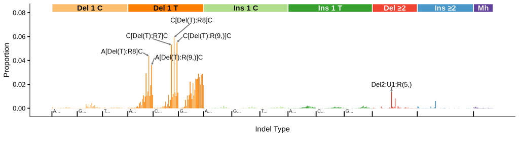

476-type spectrum of the linking tumor DRUP01330020T; cosine similarity to the extracted 476-type signature is 0.9855

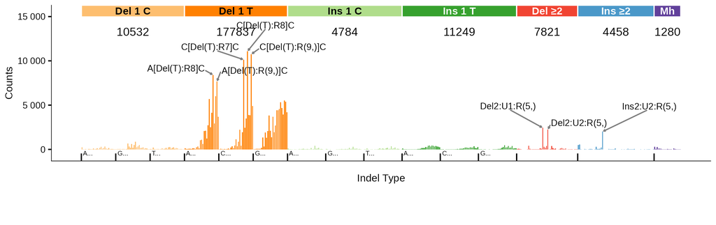

## 83-type signature corresponding to InsDel2c (C_ID2)

**Note**

InsDel2a and 2c 89-type and 476-type extractions collapse to 83-type signature close to C_ID2. InsDel2b extractions have more insertions of a single T in long poly-T contexts, which is absent in C_ID2, as well as some single T deletions in stretches of 4 and 5 T’s, which are also absent C_ID2

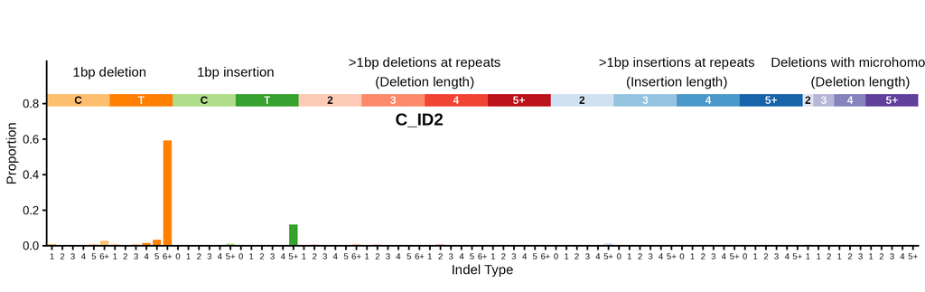

**Click here to see with insertions and deletions of T in long poly-T suppressed**

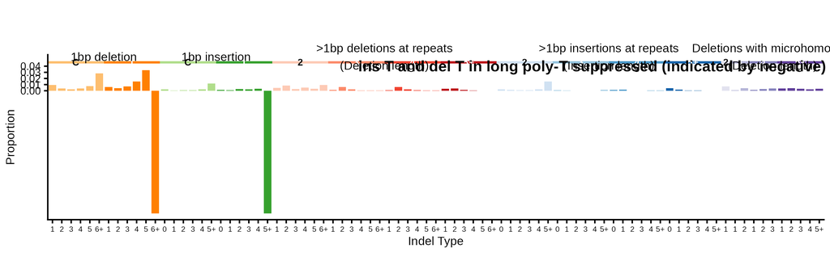

83-type signature converted from signature discovered in the 476-type spectra (using bipartite matching optimization) | cosine similarity to C_ID2: 0.9872

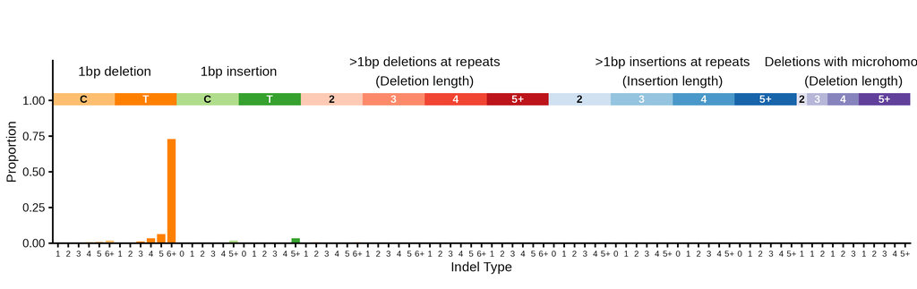

**Click here to see with insertions and deletions of T in long poly-T suppressed**

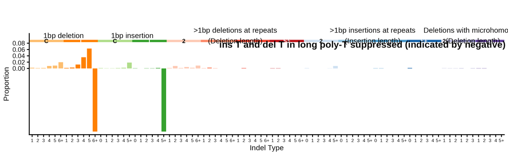

**Click to see flow diagrams: 476-type to 83-type collapse**

These Sankey diagrams show how the 476-type mutation categories are redistributed to 83-type categories using bipartite matching. We only show the diagrams for insertions or deletions of > 1 base because it is for these indels that 476-type categories map to > 1 83-type category.

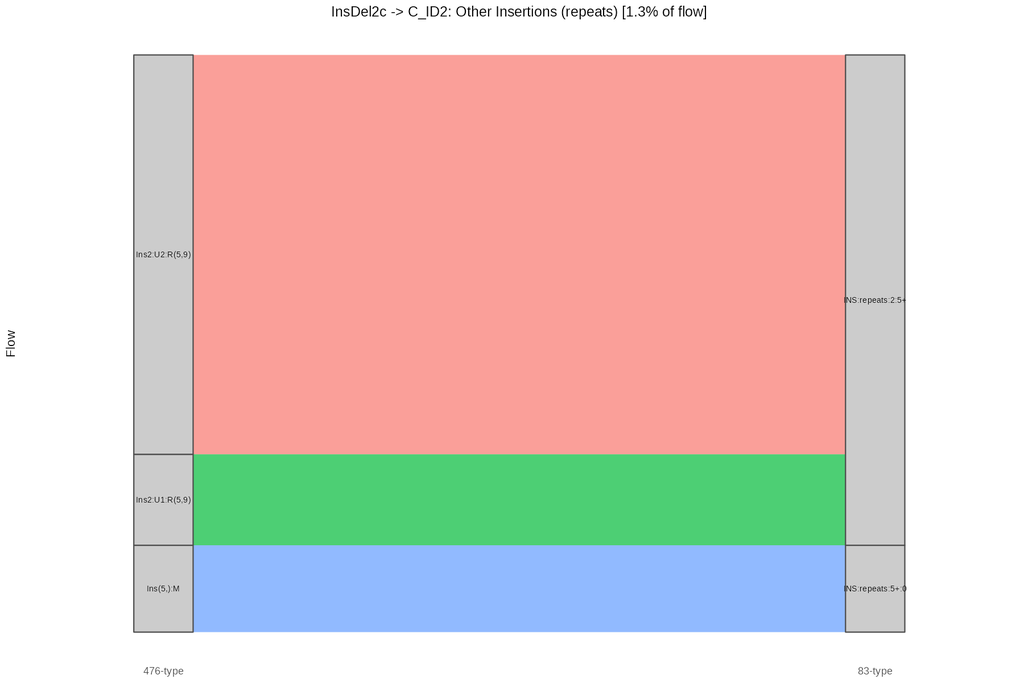

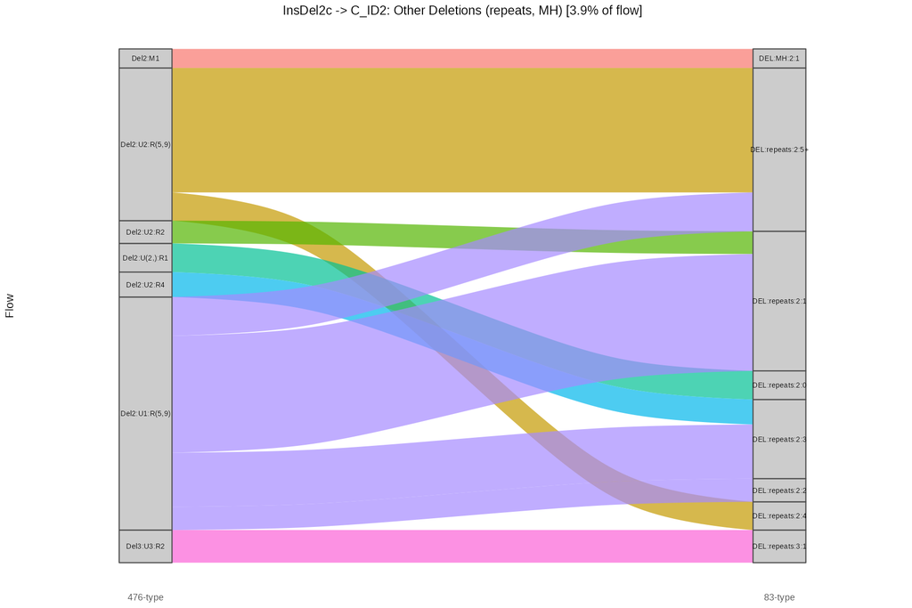

83-type spectrum of the linking tumor DRUP01330020T | cosine similarity to C_ID2: 0.9903

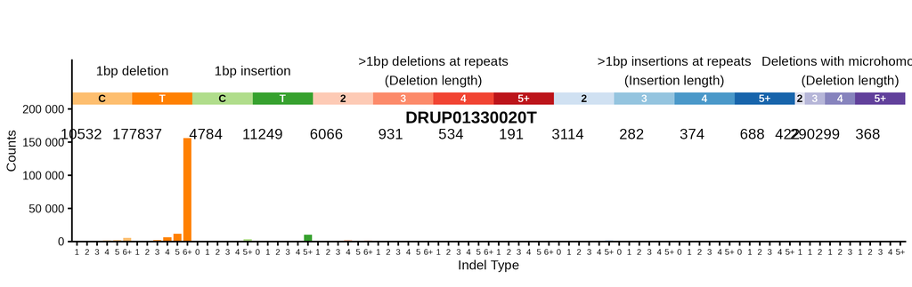

**Click here to see with insertions and deletions of T in long poly-T suppressed**

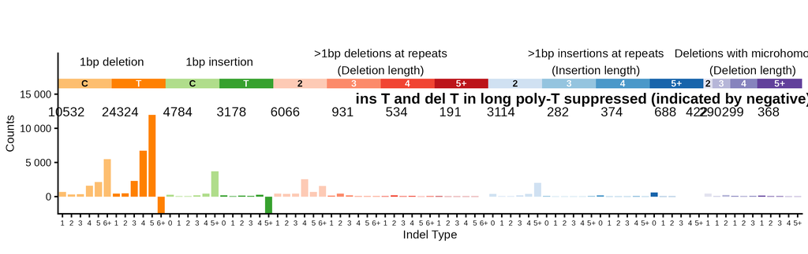

83-type spectrum of best 83-type matching tumor DRUP01080031T | cosine similarity to C_ID2: 0.9996

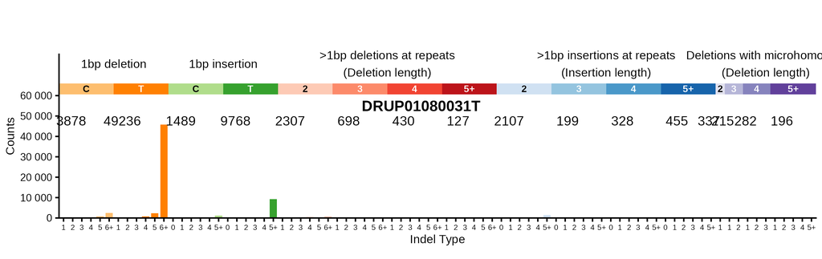

**Click here to see with insertions and deletions of T in long poly-T suppressed**

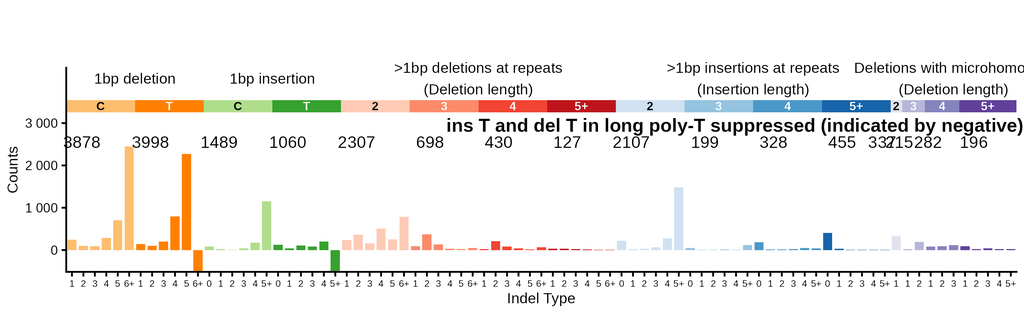

### Similar COSMIC signatures

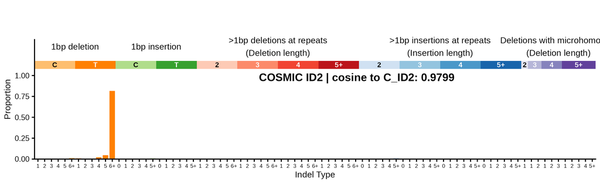

**Click here to see with insertions and deletions of T in long poly-T suppressed**

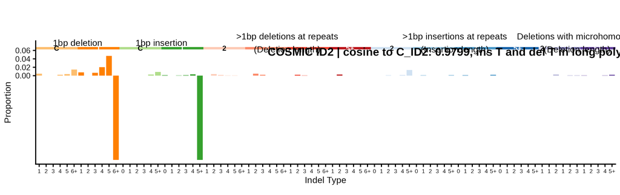

### Similar signatures from Jin et al. 2024

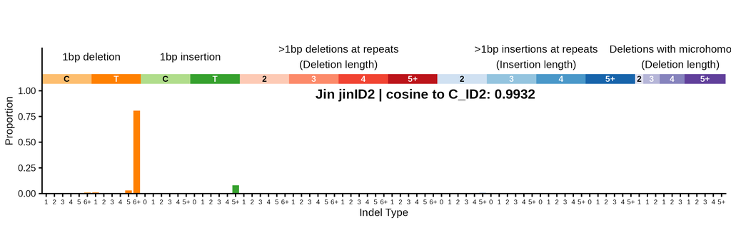

**Click here to see with insertions and deletions of T in long poly-T suppressed**

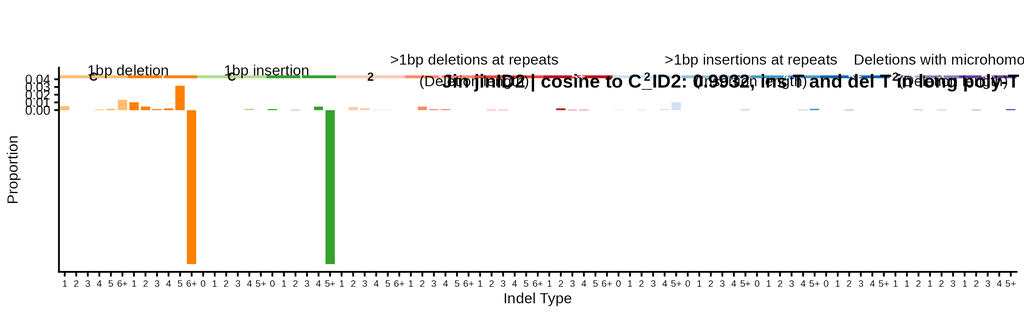